# Progetto

2023-04-14

### Record linkage - prima parte: da 2 a 6

##### 2. Effettuare il record-linkage con lo scopo di costruire l’indicatore ‘Intervento chirurgico di asportazione del tumore al seno entro 60 giorni dalla data di diagnosi’ su base mensile per i casi incidenti nel mese di gennaio 1984.

Denominatore: tutte le pazienti di sesso femminile con tumore al seno insorto tra 01/01/1984 e 31/01/1984, in stadio I o II, che hanno subito un intervento chirurgico Numeratore: tutte le pazienti al denominatore con intervallo tra la data d’incidenza e la data dell’intervento ≤60 giorni

```r
#data_deaths =read.csv("dataset/Deathregister.csv", header = TRUE, sep =";")


data_sdo = read.csv("dataset/SDO_clean.csv", header = TRUE, sep =",")

data_cancer = read.csv("dataset/cancer_clean.csv", header=TRUE, sep = ",")

dataMerge=merge(data_cancer, data_sdo, by="idnum")

dataMerge$incidenza = as.Date(dataMerge$incidenza, format = "%d/%m/%Y")
dataMerge$dataprestazione= as.Date(dataMerge$dataprestazione)
dataMerge$dimissione= as.Date(dataMerge$dimissione)

data_gerH = read.csv("dataset/German_final.csv", header=TRUE, sep = ",")
dataMerge2 = merge(dataMerge, data_gerH, by='idnum')

#pulizia
dataMerge2$Prestazione <- as.factor(dataMerge2$Prestazione)
dataMerge2$ospedale <- as.factor(dataMerge2$ospedale)
dataMerge2$Stadio <- as.factor(dataMerge2$Stadio)
dataMerge2$tipotumore <- as.factor(dataMerge2$tipotumore)
dataMerge2$geneticm <- as.factor(dataMerge2$geneticm)
dataMerge2$smoke <- as.factor(dataMerge2$smoke)
dataMerge2$sex <- as.factor(dataMerge2$sex)
dataMerge2$married <- as.factor(dataMerge2$married)
dataMerge2$kids <- as.factor(dataMerge2$kids)
dataMerge2$work <- as.factor(dataMerge2$work)
dataMerge2$education <- as.factor(dataMerge2$education)

summary(dataMerge2)
```

```
##      idnum             Stadio       incidenza            tipotumore   geneticm
##  Min.   :   3   Stadio I  :1005   Min.   :1984-01-11   altro  :2477   0:5775
##  1st Qu.:1931   Stadio II :3510   1st Qu.:1984-01-13   colon  :1300   1: 604
##  Median :3855   Stadio III: 776   Median :1984-01-15   polmone:1347
##  Mean   :3881   Stadio IV :1088   Mean   :1984-01-15   seno   :1255
##  3rd Qu.:5834                     3rd Qu.:1984-01-18
##  Max.   :7748                     Max.   :1984-01-20
##
##          Prestazione   dataprestazione        dimissione            ospedale
##  chemioterapica:1219   Min.   :1984-01-25   Min.   :1984-06-23   1      : 740
##  chirurgica    :2109   1st Qu.:1984-02-19   1st Qu.:1984-07-17   7      : 724
##  radioterapica :3051   Median :1984-03-08   Median :1984-08-02   8      : 724
##                        Mean   :1984-03-18   Mean   :1984-08-12   6      : 720
##                        3rd Qu.:1984-04-10   3rd Qu.:1984-09-01   9      : 714
##                        Max.   :1984-09-06   Max.   :1985-02-12   5      : 699
##                                                                  (Other):2058
##  smoke          sex       married     kids       work            education
##  no :5090   Female:3203   no :1388   no :3490   no :5983   low        :5717
##  yes:1289   Male  :3176   yes:4991   yes:2889   yes: 396   medium/high: 662
##
##
##
##
##
##       age
##  Min.   : 26.00
##  1st Qu.: 40.00
##  Median : 45.00
##  Mean   : 48.17
##  3rd Qu.: 54.00
##  Max.   :108.00
##
```

##### 3. Calcolare l’indicatore ‘Intervento chirurgico di asportazione del tumore al seno entro 60 giorni dalla data di diagnosi’ per ospedale e darne rappresentazione grafica, includendo come valore di riferimento nel grafico l’indicatore calcolato sull’intero dataset. Per esempi relativi alla rappresentazione grafica fare riferimento al sito Piano Nazionale Esiti (PNE) o siti analoghi trattati a lezione.

Criteri di inclusione: (commenti nostri) 1. sesso: donna 2. tumore al seno 3. Stadio I o II 4. intervallo di tempo fra diagnosi e intervento = 60 giorni 5. gennaio 1984 6. intervento chirurgico

0/1 per i 60 giorni

```r
dataMerge2$intervallo = as.numeric(dataMerge2$dataprestazione - dataMerge2$incidenza)

summary(dataMerge2$intervallo)
```

```
##    Min. 1st Qu.  Median    Mean 3rd Qu.    Max.
##    8.00   33.00   52.00   63.33   86.00  234.00
```

```r
#hist(dataMerge$intervallo[dataMerge$status==1
```

##### 4. Utilizzare il dataset ottenuto per valutare l’associazione a livello individuale tra il livello di educazione ed il valore dell’indicatore ‘Intervento chirurgico di asportazione del tumore al seno entro 60 giorni dalla data di diagnosi’. Quale misura di effetto è possibile stimare? Calcolate ed interpretate tale misura di effetto grezza. Riportare anche la relativa tabella di contingenza.

##### 5. Calcolate la stessa misura di effetto, questa volta aggiustata per la sola variabile ‘working’, mediante il metodo Mantel Haenszel. Interpretate il risultato.

##### 6. Stimate l’associazione a livello individuale tra il livello di educazione ed il valore dell’indicatore, aggiustata per tutte le variabili disponibili che ritenete opportuno inserire come potenziali confondenti, mediante un modello di regressione logistica. Interpretate i risultati. Su quanti soggetti avete effettuato l’analisi? Quali variabili sono associate all’indicatore? In che modo?

### Record linkage - seconda parte: dal punto 7 in poi

##### Considerate ora tutti i tumori al colon insorti nel gennaio 1984. Unire i data-set utili per studiare la mortalità del tumore al colon nei soggetti inclusi nell’estrazione del German health Register (dataset 1).

```r
library(survival)
library(ggplot2)
library(survminer)
#data_deaths =read.csv("dataset/Deathregister.csv", header = TRUE, sep =";")

data_death = read.csv("dataset/Deathregister.csv", header = TRUE, sep =";")
data_cancer = read.csv("dataset/cancer_clean.csv", header=TRUE, sep = ",")
dataMerge=merge(data_cancer, data_death, by="idnum")

data_gerH = read.csv("dataset/German_final.csv", header=TRUE, sep = ",")
dataMerge3 = merge(dataMerge, data_gerH, by='idnum')

## Pulizia
dataMerge3$incidenza <- as.Date(dataMerge3$incidenza, format = "%d/%m/%Y")
dataMerge3$enddate <- as.Date(dataMerge3$enddate, format = "%Y-%m-%d")
dataMerge3$Stadio <- as.factor(dataMerge3$Stadio)
dataMerge3$tipotumore <- as.factor(dataMerge3$tipotumore)
dataMerge3$geneticm <- as.factor(dataMerge3$geneticm)
dataMerge3$smoke <- as.factor(dataMerge3$smoke)
dataMerge3$sex <- as.factor(dataMerge3$sex)
dataMerge3$married <- as.factor(dataMerge3$married)
dataMerge3$kids <- as.factor(dataMerge3$kids)
dataMerge3$work <- as.factor(dataMerge3$work)
dataMerge3$education <- as.factor(dataMerge3$education)
dataMerge3$dead <- as.factor(dataMerge3$dead)

#summary(dataMerge3)
```

##### 7. Selezionate i record relativi ai tumori al colon e stimate la sopravvivenza a 5 anni. Quanti soggetti sono inclusi nell’analisi? Quanti pazienti sono morti nel periodo di interesse? Riportare graficamente la stima di sopravvivenza nei primi 5 anni dalla diagnosi stimata tramite lo stimatore di Kaplan-Meier.Stimare approssimativamente la sopravvivenza mediana.

```r
colon <- dataMerge3[dataMerge3$tipotumore=="colon",]
length(colon[colon$incidenza>colon$enddate])
```

```
## [1] 0
```

```r
table(colon$dead)
```

```
##
##   0   1
## 597 707
```

```r
colon$survtime <- as.numeric(colon$enddate-colon$incidenza)/365.25

fit<-survfit(Surv(survtime, as.numeric(dead)) ~1,data=colon)
summary(fit)
```

```
## Call: survfit(formula = Surv(survtime, as.numeric(dead)) ~ 1, data = colon)
##
##   time n.risk n.event survival  std.err lower 95% CI upper 95% CI
##  0.515   1304       1    0.999 0.000767        0.998        1.000
##  0.548   1302       1    0.998 0.001084        0.996        1.000
##  0.586   1301       1    0.998 0.001327        0.995        1.000
##  0.589   1300       1    0.997 0.001532        0.994        1.000
##  0.591   1299       1    0.996 0.001713        0.993        1.000
##  0.597   1298       2    0.995 0.002025        0.991        0.999
##  0.608   1296       1    0.994 0.002164        0.990        0.998
##  0.613   1294       1    0.993 0.002294        0.989        0.998
##  0.619   1293       1    0.992 0.002418        0.988        0.997
##  0.641   1289       1    0.992 0.002536        0.987        0.997
##  0.646   1288       1    0.991 0.002648        0.986        0.996
##  0.649   1287       1    0.990 0.002755        0.985        0.995
##  0.660   1286       2    0.988 0.002958        0.983        0.994
##  0.671   1282       1    0.988 0.003055        0.982        0.994
##  0.682   1279       1    0.987 0.003149        0.981        0.993
##  0.687   1275       2    0.985 0.003329        0.979        0.992
##  0.709   1271       1    0.985 0.003415        0.978        0.991
##  0.715   1270       1    0.984 0.003499        0.977        0.991
##  0.731   1269       1    0.983 0.003581        0.976        0.990
##  0.734   1267       1    0.982 0.003662        0.975        0.989
##  0.739   1266       1    0.982 0.003740        0.974        0.989
##  0.758   1264       1    0.981 0.003817        0.973        0.988
##  0.769   1262       1    0.980 0.003892        0.972        0.988
##  0.783   1260       1    0.979 0.003966        0.971        0.987
##  0.805   1254       1    0.978 0.004039        0.971        0.986
##  0.808   1253       2    0.977 0.004181        0.969        0.985
##  0.816   1251       2    0.975 0.004317        0.967        0.984
##  0.830   1249       1    0.974 0.004384        0.966        0.983
##  0.832   1248       2    0.973 0.004514        0.964        0.982
##  0.835   1246       1    0.972 0.004577        0.963        0.981
##  0.841   1243       1    0.971 0.004640        0.962        0.981
##  0.849   1242       1    0.971 0.004702        0.961        0.980
##  0.862   1240       1    0.970 0.004763        0.961        0.979
##  0.873   1237       1    0.969 0.004823        0.960        0.979
##  0.876   1236       2    0.967 0.004941        0.958        0.977
##  0.884   1234       1    0.967 0.004999        0.957        0.977
##  0.887   1233       1    0.966 0.005056        0.956        0.976
```

[output cut: 503 more lines]

```
##  4.775    131       1    0.257 0.016657        0.227        0.292
##  4.789    126       1    0.255 0.016649        0.225        0.290
##  4.791    124       1    0.253 0.016641        0.223        0.288
##  4.794    123       1    0.251 0.016633        0.221        0.286
##  4.797    122       1    0.249 0.016623        0.218        0.284
##  4.802    121       2    0.245 0.016602        0.214        0.280
##  4.816    117       1    0.243 0.016591        0.212        0.278
##  4.819    116       1    0.241 0.016580        0.210        0.276
##  4.824    115       1    0.239 0.016567        0.208        0.273
##  4.838    111       1    0.236 0.016557        0.206        0.271
##  4.854    107       1    0.234 0.016549        0.204        0.269
##  4.893     99       1    0.232 0.016550        0.202        0.267
##  4.895     97       1    0.230 0.016551        0.199        0.264
##  4.901     96       2    0.225 0.016548        0.195        0.260
##  4.942     89       1    0.222 0.016554        0.192        0.257
```

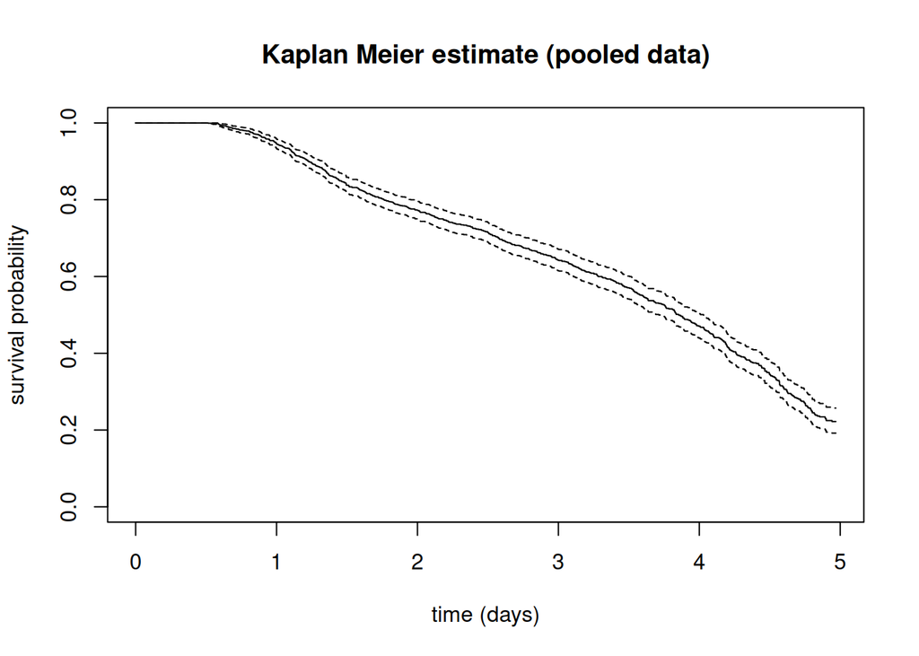

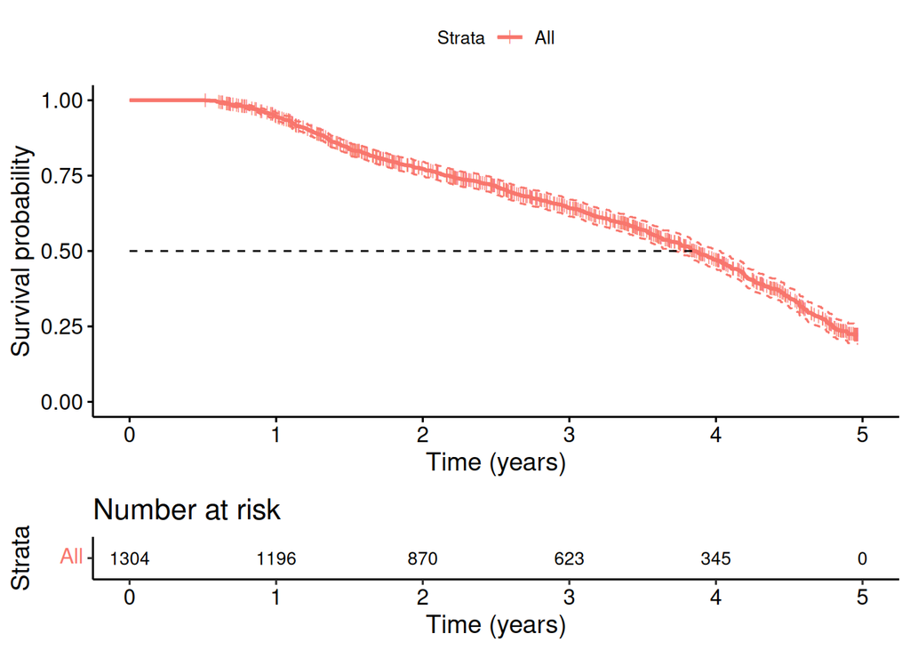

```r
plot(fit, xlab='time (days)', ylab='survival probability')
title('Kaplan Meier estimate (pooled data)')

ggsurvplot(fit, data = colon, risk.table = TRUE, conf.int = TRUE, conf.int.fill = "black", conf.int.style = "step", surv.median.line = "h", censor.size=2.5, risk.table.fontsize = 3.5, censor.shape="|", xlab="Time (years)")
```

##### 8. Stimare la sopravvivenza nei primi 5 anni dalla diagnosi per Stadio e effettuare un test d’ipotesi per verificare se l’azzardo di morte sia diverso per stadio di malattia alla diagnosi.

```r
fit<-survfit(Surv(survtime, as.numeric(dead)) ~ Stadio,data=colon)
summary(fit)
```

```
## Call: survfit(formula = Surv(survtime, as.numeric(dead)) ~ Stadio,
##     data = colon)
##
##                 Stadio=Stadio I
##   time n.risk n.event survival std.err lower 95% CI upper 95% CI
##  0.586    228       1    0.996 0.00438        0.987        1.000
##  0.641    225       1    0.991 0.00620        0.979        1.000
##  0.660    224       1    0.987 0.00759        0.972        1.000
##  0.709    220       1    0.982 0.00878        0.965        1.000
##  0.731    219       1    0.978 0.00982        0.959        0.997
##  0.783    218       1    0.973 0.01075        0.952        0.995
##  0.816    216       1    0.969 0.01161        0.946        0.992
##  0.884    213       1    0.964 0.01241        0.940        0.989
##  0.917    212       1    0.960 0.01316        0.934        0.986
##  0.923    211       1    0.955 0.01386        0.928        0.983
##  0.925    210       1    0.951 0.01452        0.923        0.980
##  0.945    208       1    0.946 0.01516        0.917        0.976
##  0.986    207       1    0.941 0.01576        0.911        0.973
##  1.029    205       1    0.937 0.01633        0.905        0.969
##  1.106    203       1    0.932 0.01689        0.900        0.966
##  1.177    202       1    0.928 0.01743        0.894        0.962
##  1.205    200       1    0.923 0.01795        0.888        0.959
##  1.221    198       1    0.918 0.01845        0.883        0.955
##  1.257    196       1    0.914 0.01894        0.877        0.952
##  1.322    192       1    0.909 0.01943        0.872        0.948
##  1.331    190       1    0.904 0.01991        0.866        0.944
##  1.432    185       1    0.899 0.02040        0.860        0.940
##  1.492    184       1    0.894 0.02086        0.854        0.936
##  1.495    183       1    0.889 0.02131        0.849        0.932
##  1.517    182       1    0.885 0.02175        0.843        0.928
##  1.588    177       1    0.880 0.02219        0.837        0.924
##  1.613    174       1    0.875 0.02263        0.831        0.920
##  1.632    173       1    0.869 0.02306        0.825        0.916
##  1.637    172       1    0.864 0.02347        0.820        0.912
##  1.640    171       2    0.854 0.02426        0.808        0.903
##  1.678    167       1    0.849 0.02465        0.802        0.899
##  1.697    165       2    0.839 0.02540        0.791        0.890
##  1.758    161       1    0.834 0.02578        0.785        0.886
##  1.763    160       1    0.828 0.02614        0.779        0.881
##  1.832    157       1    0.823 0.02650        0.773        0.877
```

[output cut: 612 more lines]

```
##  4.572     21       1   0.1184 0.02421       0.0793       0.1768
##  4.575     20       1   0.1125 0.02371       0.0744       0.1700
##  4.591     18       1   0.1063 0.02320       0.0693       0.1630
##  4.602     17       1   0.1000 0.02266       0.0641       0.1559
##  4.616     16       1   0.0938 0.02209       0.0591       0.1488
##  4.649     15       1   0.0875 0.02148       0.0541       0.1416
##  4.668     14       1   0.0813 0.02084       0.0492       0.1343
##  4.704     13       1   0.0750 0.02015       0.0443       0.1270
##  4.717     12       1   0.0688 0.01942       0.0395       0.1196
##  4.753     11       2   0.0563 0.01779       0.0303       0.1045
##  4.789      8       1   0.0492 0.01690       0.0251       0.0965
##  4.794      7       1   0.0422 0.01588       0.0202       0.0882
##  4.797      6       1   0.0352 0.01471       0.0155       0.0798
##  4.802      5       1   0.0281 0.01334       0.0111       0.0713
##  4.824      3       1   0.0188 0.01173       0.0055       0.0639
```

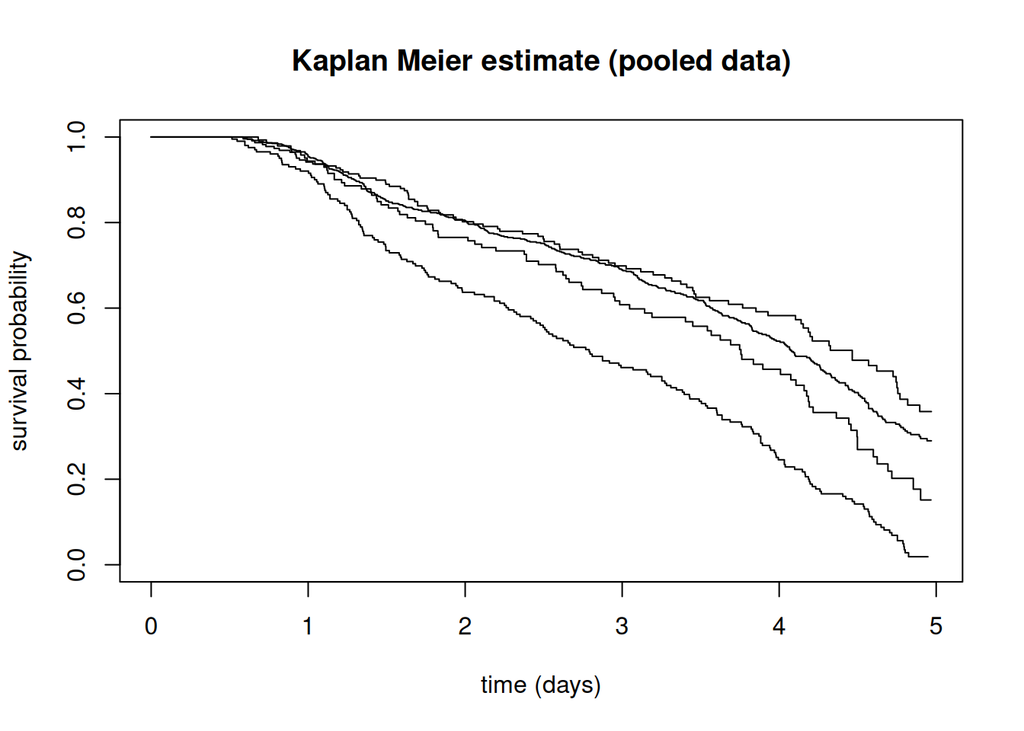

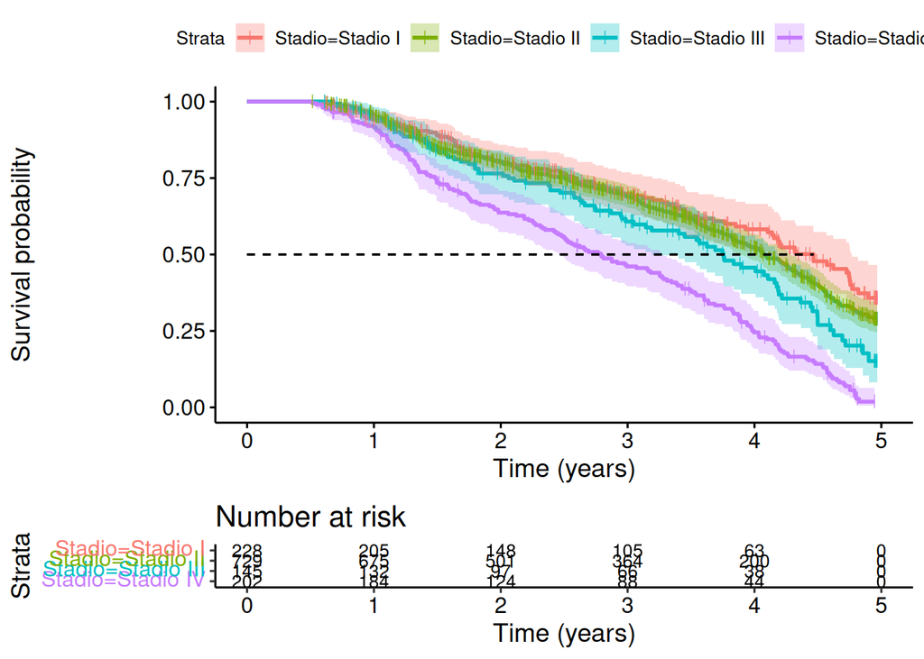

```r
plot(fit, xlab='time (days)', ylab='survival probability')
title('Kaplan Meier estimate (pooled data)')

ggsurvplot(fit, data = colon, risk.table = TRUE, conf.int = TRUE, surv.median.line = "h", censor.size=2.5, risk.table.fontsize = 3.5, censor.shape="|", xlab="Time (years)")
```

##### 9. Applicare un modello per valutare l’associazione tra sesso e mortalità e interpretare la misura di effetto stimata.

##### 10. Quali variabili sono associate alla mortalità? Riportare le relative stime di effetto con gli intervalli di confidenza.

##### 11. Valutare la presenza di confondenti e/o modificatori di effetto tra le variabili disponibili nel German health register e nel registro tumori nella valutazione dell’associazione tra sesso e mortalità. Se identificate un’interazione tra sesso e un’altra variabile riportare le stime di effetto per maschi e femmine separatamente e commentare il tipo di interazione trovato.

##### 12. A seguito delle considerazioni effettuate nei punti precedenti scegliete un modello finale per valutare i fattori di rischio della mortalità dopo diagnosi di tumore al colon e commentate i risultati.